# Penguins: MANOVA and HE plots

Michael Friendly

6/14/2020

## Introduction

The [multivariate EDA](https://rpubs.com/friendly/penguin-biplots) of the `penguins` data brought some simplicity to understanding the quantitative variables of body mass, flipper length and the two bill variables. One main virtue of the graphical methods used there was that `species` could be represented visually in the plot and annotated with separate data ellipses and regression lines, even though the principal component analysis and biplot did not include species in the analysis.

An obvious next step, and the one that brought the `iris` data to prominence is to ask two related multivariate model questions:

- **MANOVA**: To what extent can we be confident that the means of species on these variables reliably differ significantly in multivariate space? A multivariate analysis of variance (MANOVA) tests group mean differences simultaneously, without appeal to univariate tests or correction for multiple testing.
- **Discriminant analysis**: What weighted sums of the variables best discriminates among the penguin species? The answer to this question is that the discriminant weights are found in the MANOVA, and are the weights that maximize the multivariate test statistics.

These ideas are implemented in the `heplots` (**heplots?**) and `candisc` (**candisc?**) packages and described in more detail in other articles (Friendly 2007; Friendly, Monette, and Fox 2013).

### Multivariate visualization

But there is more:

- **HE plots**: Hypothesis-Error plots use ellipses to show the strength of evidence for any multivariate hypothesis
- **Canonical views**: Project the data and ellipses into the low-dimensional space that shows the largest multivariate effects.

### Getting started

```r
data(penguins, package="palmerpenguins")
```

As before, we clean the data: abbreviating variable names, making some character variables factors, and removing missing data.

```r
peng <- penguins %>%
    rename(
         bill_length = bill_length_mm,
         bill_depth = bill_depth_mm,
         flipper_length = flipper_length_mm,
         body_mass = body_mass_g
         ) %>%
  mutate(species = as.factor(species),
         island = as.factor(island),
         sex = as.factor(substr(sex,1,1))) %>%
  filter(!is.na(bill_depth),
         !is.na(sex))
```

### Load our packages

```r
library(car)
library(heplots)
library(candisc)
```

## MANOVA

Let’s assume that the goal of an analysis is to determine whether and how the penguin species differ in terms of the four quantitative variables. A naive multivariate linear model is the following, with species as the only predictor.

```r
peng.mod0 <-lm(cbind(bill_length, bill_depth, flipper_length, body_mass) ~
                 species, data=peng)
Anova(peng.mod0)
```

```
##
## Type II MANOVA Tests: Pillai test statistic
##         Df test stat approx F num Df den Df Pr(>F)
## species  2      1.64      371      8    656 <2e-16 ***
## ---
## Signif. codes:  0 '***' 0.001 '**' 0.01 '*' 0.05 '.' 0.1 ' ' 1
```

## HE plots

In a univariate ANOVA, the $F$-test is based on the variability **between** groups relative to the variability **within** groups
$$F = \frac{SS_H/df_h}{SS_E / df_e}$$
The analogous multivariate tests are based on the same idea, applied to the between-group sum of squares and cross-products (SSP) matrix, $\mathbf{H}$, relative to the within-group SSP matrix, $\mathbf{E}$.

To see this visually, consider a plot of the two `bill` beak variables where we show only the data ellipses for each species and the pooled data ellipse of the residuals.

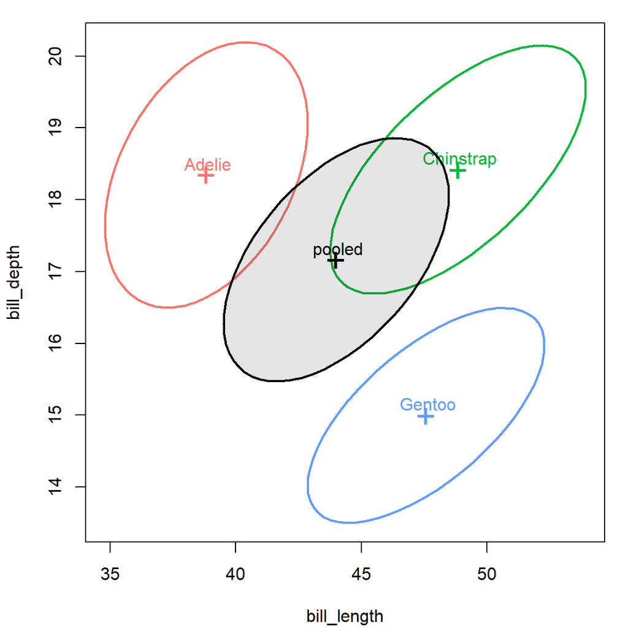

```r
cols = c(scales::hue_pal()(3), "black")
covEllipses(peng[,3:4], peng$species,
            col=cols,
            fill=c(rep(FALSE,3), TRUE), fill.alpha=.1)
```

In the HE plot below,

- the differences **between** species means are shown by what we call the $\mathbf{H}$ ellipsoid, the data ellipsoid of the fitted (predicted) values under the model. In 2D, with a two degree-of-freedom test, $\mathbf{H}$ has two dimensions and appears as a simple ellipse.
- the variation **within** species is reflected in the $\mathbf{E}$ ellipse, which is just the pooled data ellipses of the groups, translated to the grand means, or equivalently, the data ellipse of the residuals. By default, the size of the ellipse is set to cover 68% of the observations in a bivariate normal sample, an analog of a $\bar{y} \pm 1 s$ univariate interval. With this 68% interval, you can “read” the residual standard deviation as the half-length of the shadow of the $\mathbf{E}$ ellipse on any axis. Translating this ellipse to the grand means allows us to show the group centroids on the same scale, facilitating interpretation.

The orientation of the $\mathbf{H}$ ellipse reflects the negative correlation of the species means: in general species with larger bill depth have smaller bill length.

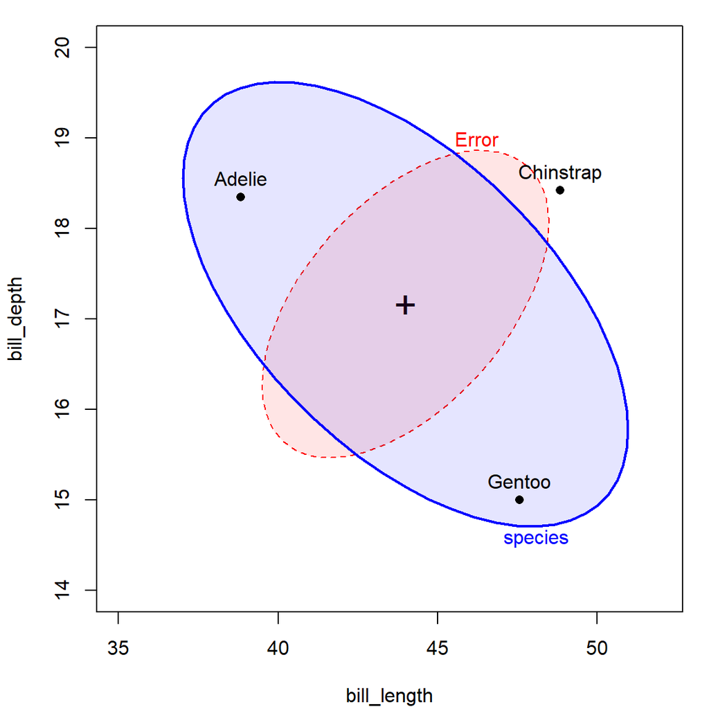

```r
heplot(peng.mod0, fill=TRUE, fill.alpha=0.1,
       size="effect",
       xlim=c(35,52), ylim=c(14,20))
```

But the overall size of the $\mathbf{H}$ ellipse relative to that of $\mathbf{E}$ is crucial:

- One simple choice, **effect size** scaling, uses $\mathbf{H}/df_e$ to put this on the same scale as the $\mathbf{E}$ ellipse. This is analogous to an effect size index used in univariate models, e.g., $ES = (\bar{y}_1 - \bar{y}_2) / s$ in a two-group design.

In the plot above, a visual estimate is that variation of the species means is about ES = 1.5 times that of within-species (residual) variance. This is a large effect!

- The default used in `heplot` is what we call **significance** (or “evidence”) scaling. That is the relative size of the $\mathbf{H}$ ellipse is set so that in the full p-dimensional space of all $p$ response variables, the $\mathbf{H}$ ellipse will protrude somewhere outside the $\mathbf{E}$ ellipse *if and only if* the test for some effect is significant (by Roy’s largest root test) at a prescribed $\alpha$-level (0.05 by default). This scaling uses $\mathbf{H}/\lambda_\alpha \: df_e$, where $\lambda_\alpha$ is the critical $\alpha$ value of Roy’s test statistic.

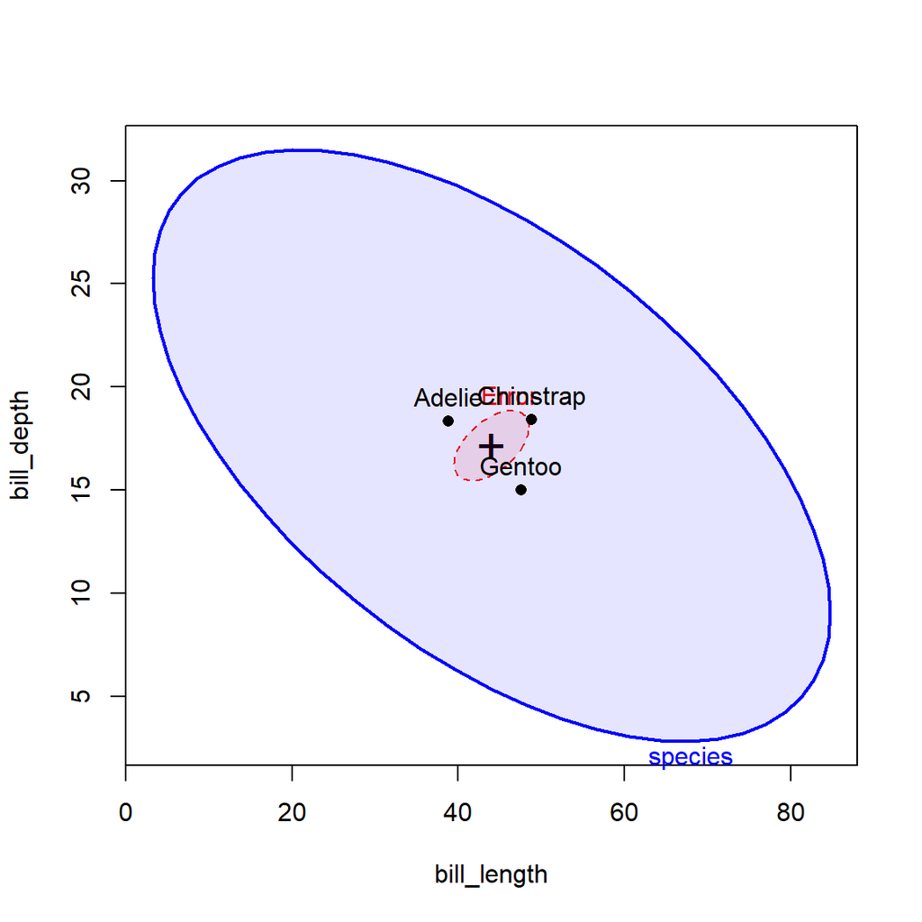

```r
heplot(peng.mod0, fill=TRUE, fill.alpha=0.1)
```

The MANOVA test is so overwhelmingly significant that I will stick to effect-size scaling to preserve resolution.

### Contrasts

One lovely virtue of the standard linear model fit with `lm()` is that any ANOVA effect of $df_h \ge 2$ degrees of freedom can be partitioned into $df_h$ separate 1 df tests of “linear hypotheses”. If these use *orthogonal* contrasts, then the separate $\mathbf{H}$ matrices are additive.

$$\begin{equation*}
\mathbf{H} = \mathbf{H}_1 + \mathbf{H}_2 + \cdots +
\mathbf{H}_{\textrm{df}_h}
\end{equation*}$$

Let’s also assume that in addition to the overall question, the researchers are interested in two sub-hypotheses:

- Do Gentoo penguins differ from the other two?
- Do Adelie differ from Chinstrap?

```r
contrasts(peng$species)<-matrix(c(1,-1,0, -1, -1, -2), 3,2)
contrasts(peng$species)
```

```
##           [,1] [,2]
## Adelie       1   -1
## Chinstrap   -1   -1
## Gentoo       0   -2
```

In the `heplots` package, contrasts are specified as a list of tests evaluated by `car::linearHypothesis`. Each of these generate an $\mathbf{H}$ matrix of rank 1, so these will appear as lines in an HE plot.

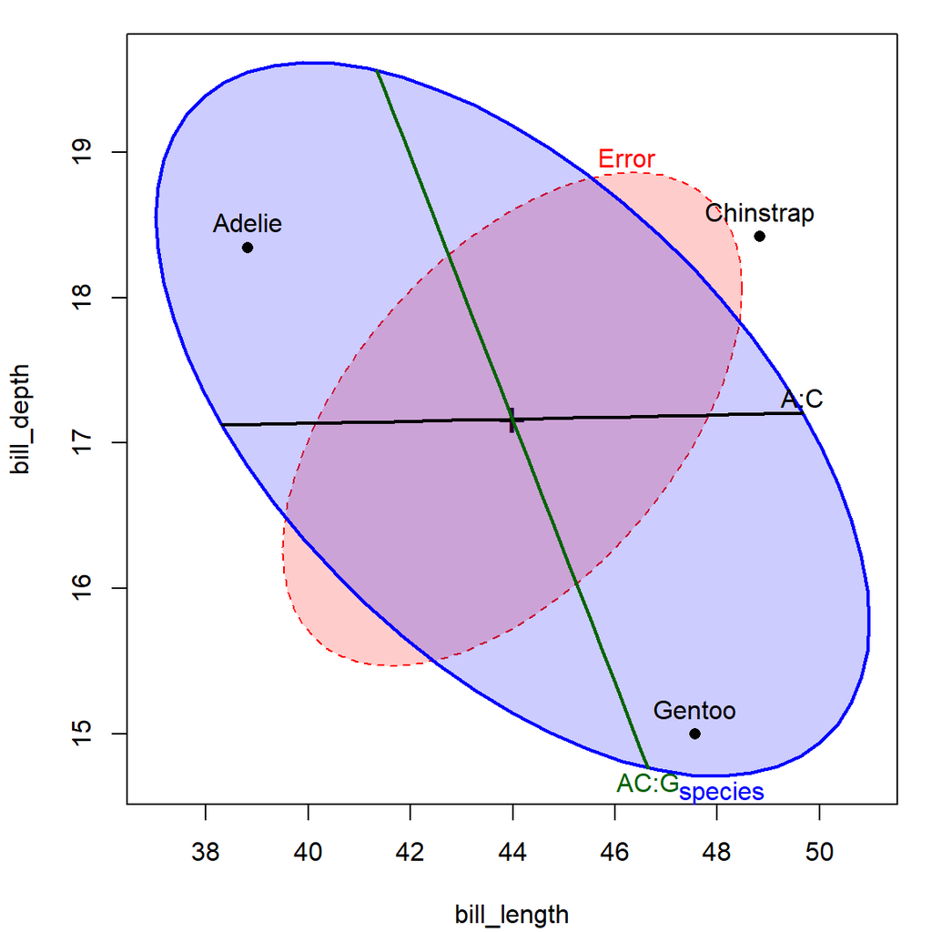

```r
peng.mod0 <-lm(cbind(bill_length, bill_depth, flipper_length, body_mass) ~ species, data=peng)

hyp <- list("A:C"="species1","AC:G"="species2")
heplot(peng.mod0, fill=TRUE, fill.alpha=0.2,
       hypotheses=hyp, size="effect")
```

This is quite a nice result. It is clear that Adelie & Chinstrap differ only in the length of the bill. Gentoo penguins differ from the other two in having longer, but less deep bill.

### Other plots

`heplot` gives 2D plots for any pair of response variables. For `flipper_length` and `body_mass` we get the plot below. It is readily seen that these two variables are highly correlated in their species means. We can interpret the major axis of this **H** ellipse as a measure of pengiun size, with Gentoo being the largest.

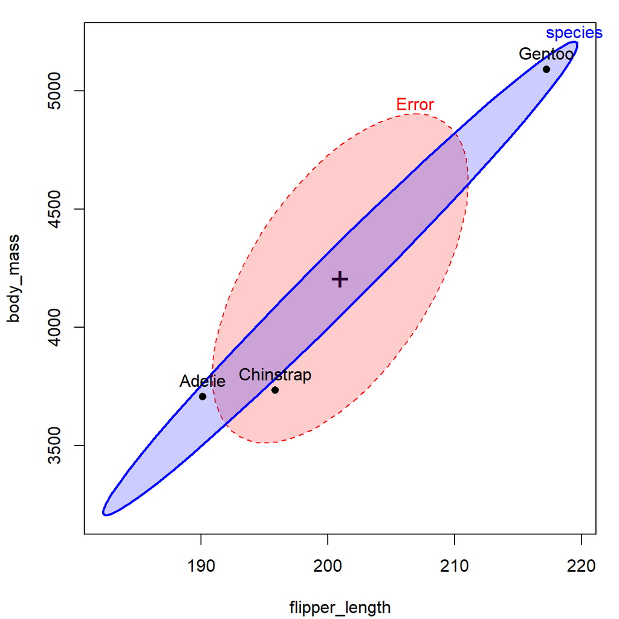

```r
heplot(peng.mod0, variables=3:4,
       size="effect",
       fill=TRUE, fill.alpha=0.2)
```

#### Pairs plots

The `pairs.mlm` method for `mlm` objects gives a all pairwise heplots in a scatterplot matrix format.

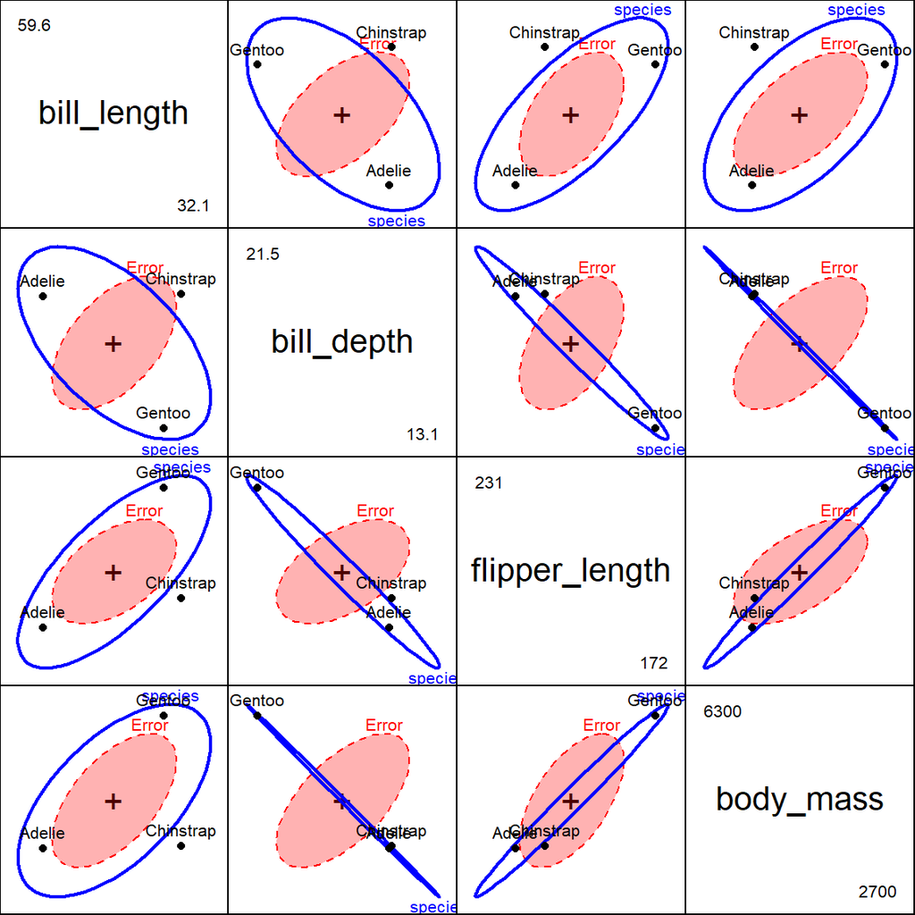

```r
pairs(peng.mod0, size="effect", fill=c(TRUE, FALSE))
```

#### 3D plots

Finally, there is an `heplot3d()` fundtion that shows the **H** and **E** ellipsoids in 3D space. This plot should be interactive in an HTML document (drag to rotate, zoom in/out with mouse wheel).

```r
next3d()
heplot3d(peng.mod0, fill=TRUE, fill.alpha=0.2, size="effect")
```

[interactive chart not shown]

If you rotate the plot, you will see that the **H** ellipsoid is actually 2-dimensional, because there are $g-1 = 2$ df.

## Other models

A careful researcher would also wonder, from a modeling perspective, whether differences among species could be accounted for by possible confounders: `island` and `sex`.

```r
peng.mod1 <-lm(cbind(bill_length, bill_depth, flipper_length, body_mass) ~
                 species + island + sex, data=peng)
Anova(peng.mod1)
```

```
##
## Type II MANOVA Tests: Pillai test statistic
##         Df test stat approx F num Df den Df Pr(>F)
## species  2     1.493    239.3      8    650 <2e-16 ***
## island   2     0.029      1.2      8    650   0.31
## sex      1     0.642    145.1      4    324 <2e-16 ***
## ---
## Signif. codes:  0 '***' 0.001 '**' 0.01 '*' 0.05 '.' 0.1 ' ' 1
```

`island` seems not to be important, so we delete this

```r
peng.mod2 <-lm(cbind(bill_length, bill_depth, flipper_length, body_mass) ~
                 species + sex, data=peng)
Anova(peng.mod2)
```

```
##
## Type II MANOVA Tests: Pillai test statistic
##         Df test stat approx F num Df den Df Pr(>F)
## species  2      1.66      392      8    654 <2e-16 ***
## sex      1      0.64      145      4    326 <2e-16 ***
## ---
## Signif. codes:  0 '***' 0.001 '**' 0.01 '*' 0.05 '.' 0.1 ' ' 1
```

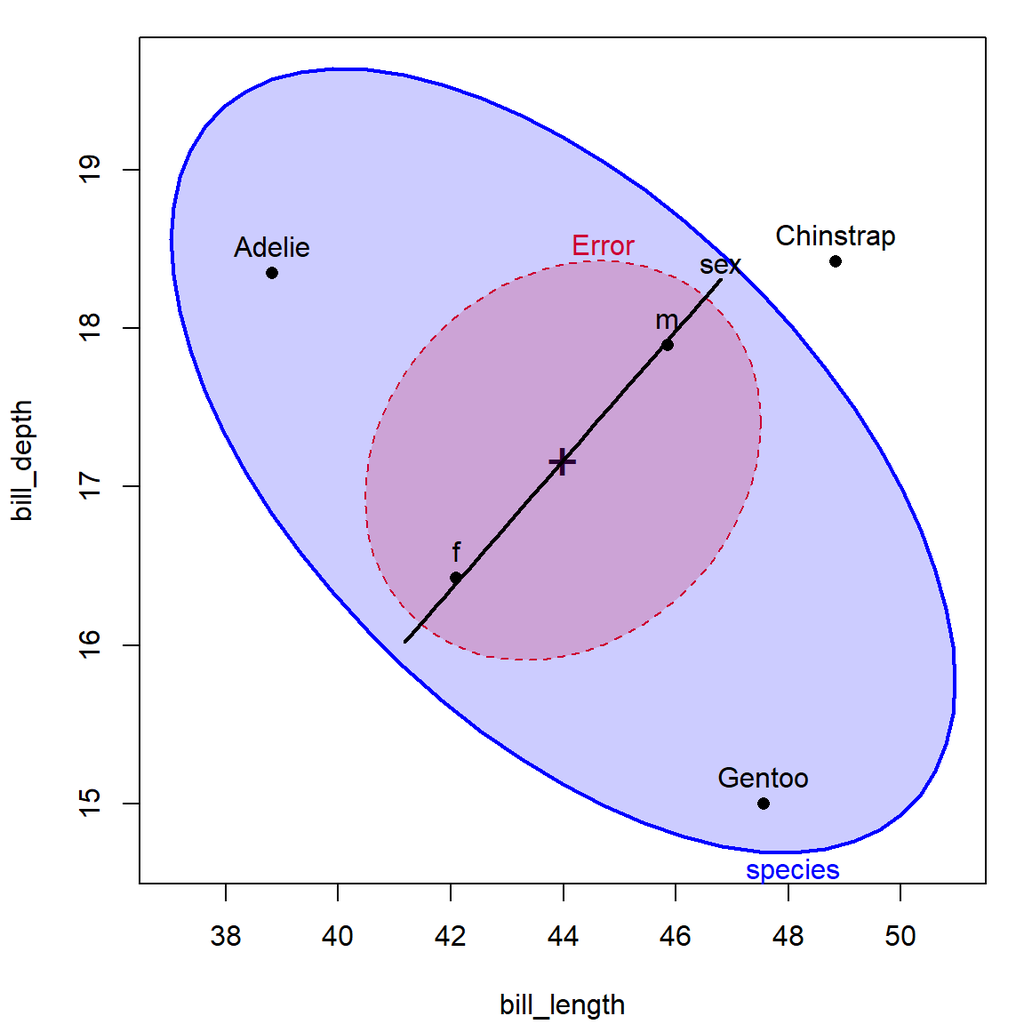

```r
heplot(peng.mod2, size="effect",
       fill=TRUE, fill.alpha=0.2)
```

So, in addition to the means among species, we also see that male penguins have both larger and deeper bills. We could go further to test for an interaction of species with sex, using `cbind( ...) ~ species:sex` for the model.

## Canonical views

The `heplot()`, `pairs.mlm()`, and `heplot3d()` functions provide 2D and 3D views of all effects in a MLM in **variable** space. Alternatively, canonical discriminant analysis (CDA) provides a low-D visualization of between-group variation and vectors reflecting the weights of the response variables on these dimensions in **canonical space**.

You can imagine this as rotating the 4D space of all four variables, and projecting the observations on the plane that shows the largest variation in the species means.

In this space, the response variables can be shown as vectors, whose angles relative to the canonical dimensions reflect their correlations. The relative lengths of these vectors indicates their contribution to discrimination among species.

This is analogous to a biplot often used in conjunction with a principal component analysis. See: [penguins_biplots](https://rpubs.com/friendly/penguin-biplots)

```r
(peng.can <- candisc(peng.mod0))
```

```
##
## Canonical Discriminant Analysis for species:
##
##   CanRsq Eigenvalue Difference Percent Cumulative
## 1  0.938      15.03       12.7    86.5       86.5
## 2  0.700       2.34       12.7    13.5      100.0
##
## Test of H0: The canonical correlations in the
## current row and all that follow are zero
##
##   LR test stat approx F numDF denDF Pr(> F)
## 1       0.0187      516     8   654  <2e-16 ***
## 2       0.2997      255     3   328  <2e-16 ***
## ---
## Signif. codes:  0 '***' 0.001 '**' 0.01 '*' 0.05 '.' 0.1 ' ' 1
```

The `plot()` method for `candisc` objects plots the canonical discriminant scores in 2D space, with the data ellipses for each group. The variable vectors reflect the correlations of each variable with the two canonical dimensions.

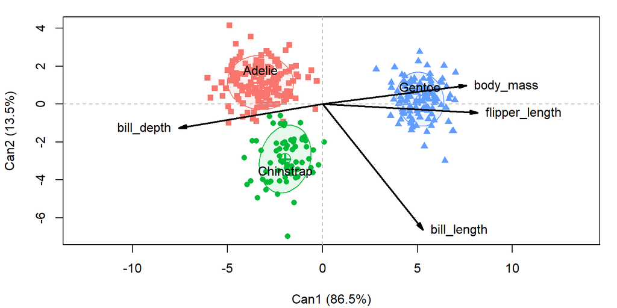

```r
col <- scales::hue_pal()(3)
plot(peng.can, col=col, pch=15:17,
     ellipse=TRUE, scale=9,
     var.lwd = 2, var.col = "black")
```

From this we can see:

- The first dimension (Can1) separates Gentoo from the other two species. Can2 largely separates Adelie from Chinstrap.
- Can1 is positively correlated with flipper length and body mass, our penguin “size” variables. But bill depth also separates Gentoo from the others, in the opposite direction
- Can2 here largely reflects bill length, with Chintrap having longer beaks than the other two.

## References

Friendly, Michael. 2007. “HE Plots for Multivariate General Linear Models.” *Journal of Computational and Graphical Statistics* 16 (2): 421–44. https://doi.org/10.1198/106186007X208407.

Friendly, Michael, Georges Monette, and John Fox. 2013. “Elliptical Insights: Understanding Statistical Methods Through Elliptical Geometry.” *Statistical Science* 28 (1): 1–39. https://doi.org/10.1214/12-STS402.